# Series_de_Tiempo_Segundo_Parcial_v2

### Vamos a descomponer la data usando el metodo decompose para entender sus componentes de tren, seasonalidad y aleatorio de la Serie 2 (PEA en México)

```r
PEA_mex_ts_decompose <- decompose(PEA_mex_ts)
summary(PEA_mex_ts_decompose)
```

```
##          Length Class  Mode
## x        72     ts     numeric
## seasonal 72     ts     numeric
## trend    72     ts     numeric
## random   72     ts     numeric
## figure    4     -none- numeric
## type      1     -none- character
```

Vamos a plotear la desmposición

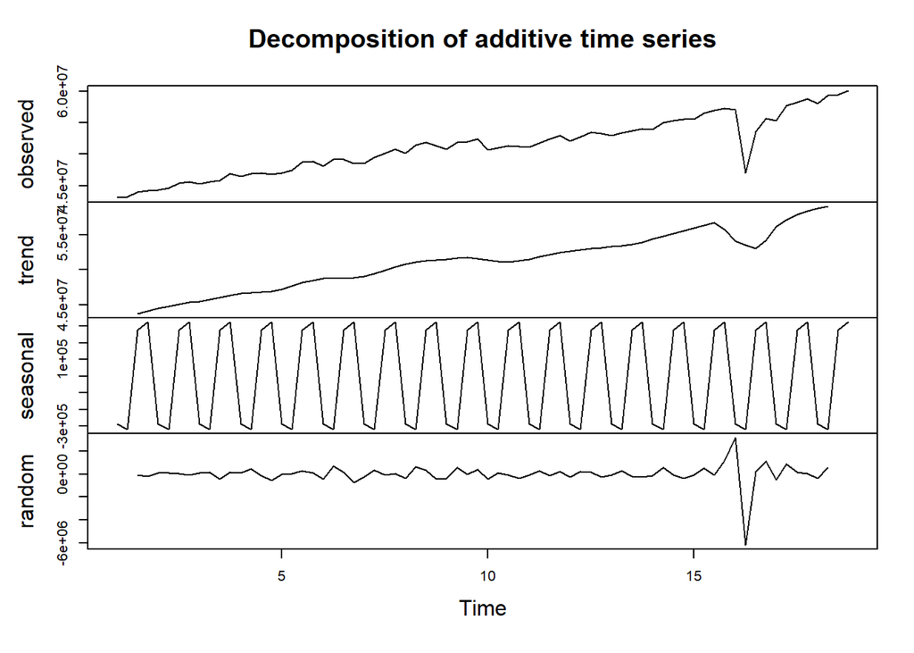

```r
plot(PEA_mex_ts_decompose)
```

Se observa claramente una tendencia creciente (excepto en años 2020 y 2021 derivado de pandemia de Covid-19). Se observa una estacionalidad por 4trimestres donde el 1er cuatrimestre de cada año es el más bajo y e último el más alto.

### Analicemos los valores de la variable Y

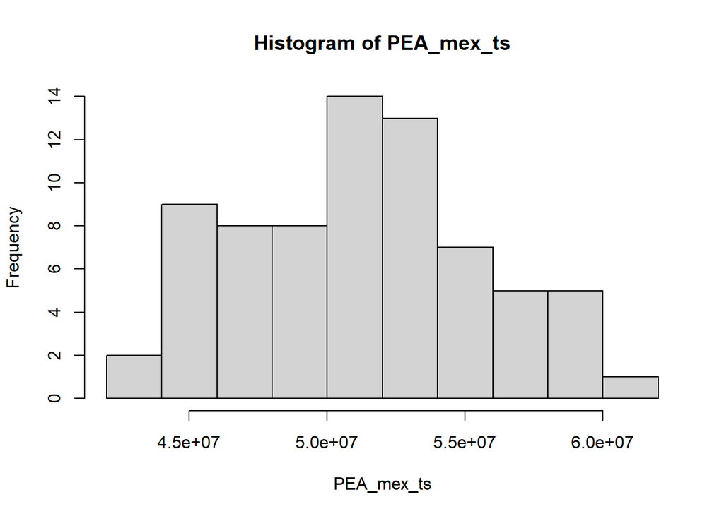

```r
hist(PEA_mex_ts)
```

```r
summary(PEA_mex_ts)
```

```
##     Min.  1st Qu.   Median     Mean  3rd Qu.     Max.
## 43099847 47334584 51341390 51224328 53960600 60145456
```

```r
library(e1071)

# Calculate skewness
skewness_value_serie_PEA <- skewness(PEA_mex_ts)

# Calculate kurtosis
kurtosis_value_serie_PEA <- kurtosis(PEA_mex_ts)

# Print the results
print(paste("Skewness:", skewness_value_serie_PEA))
```

```
## [1] "Skewness: 0.0687526722306482"
```

```r
print(paste("Kurtosis:", kurtosis_value_serie_PEA))
```

```
## [1] "Kurtosis: -0.895652562771184"
```

#### Separamos el en data sets train y test de la Serie 2 (PEA en México)

Se tienen 72 datos, por lo que el train será de 66 datos, para que el test sea de 6 datos o 6 trimestres

```r
# Split the data into training and testing sets


# Subset the data to keep rows from the beginning until train_end and all columns
PEA_mex_ts_train <- PEA_mex_ts[1:66]
head(PEA_mex_ts_train)
```

```
## [1] 43099847 43180433 44000204 44245519 44306012 44611672
```

```r
tail(PEA_mex_ts_train)
```

```
## [1] 57014967 46978848 53571791 55653440 55385133 57668254
```

```r
# Subset the data to keep rows from the beginning until train_end and all columns


# Subset the data to keep rows from the beginning until train_end and all columns
PEA_mex_ts_test <- PEA_mex_ts[67:72]
head(PEA_mex_ts_test)
```

```
## [1] 58307446 58761793 58085314 59338419 59480471 60145456
```

```r
tail(PEA_mex_ts_test)
```

```
## [1] 58307446 58761793 58085314 59338419 59480471 60145456
```

## Modelo SARIMA para Serie 2 (PEA en México)

#### Determinación de ACF & PACF para el caso de la Serie 2 (PEA en México) sin diferneciar

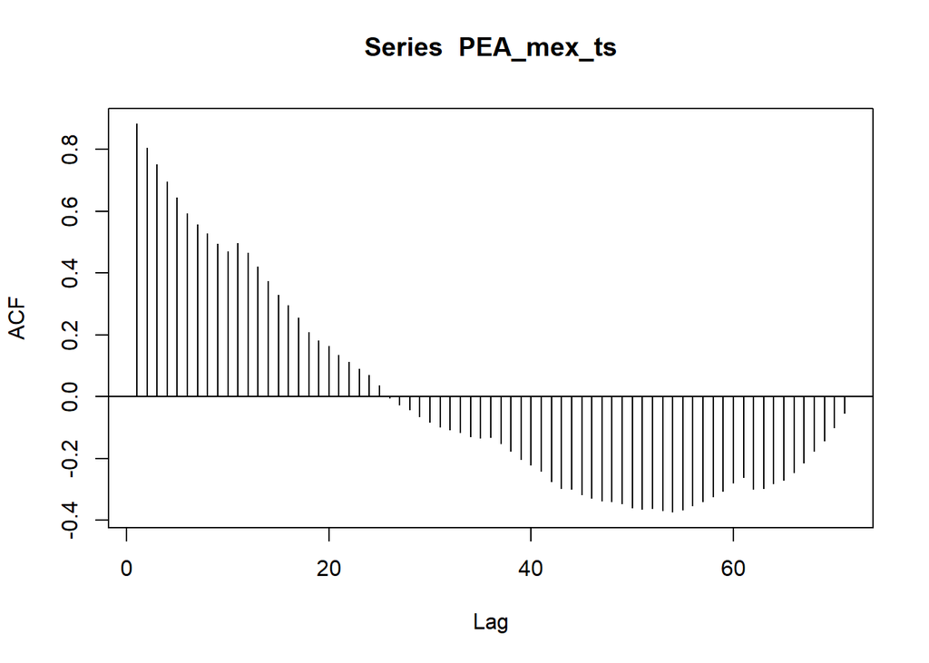

```r
#install.packages("forecast")
library(forecast)

#par(mfrow=c(2,1))

acf_PEA_mex_ts_sin_diferenciar <- Acf(PEA_mex_ts, lag.max = 100, ci.type = "ma")
```

```r
head(acf_PEA_mex_ts_sin_diferenciar)
```

```
##
## Autocorrelations of series 'PEA_mex_ts', by lag
##
##     1     2     3     4     5     6
## 0.883 0.806 0.753 0.697 0.644 0.594
```

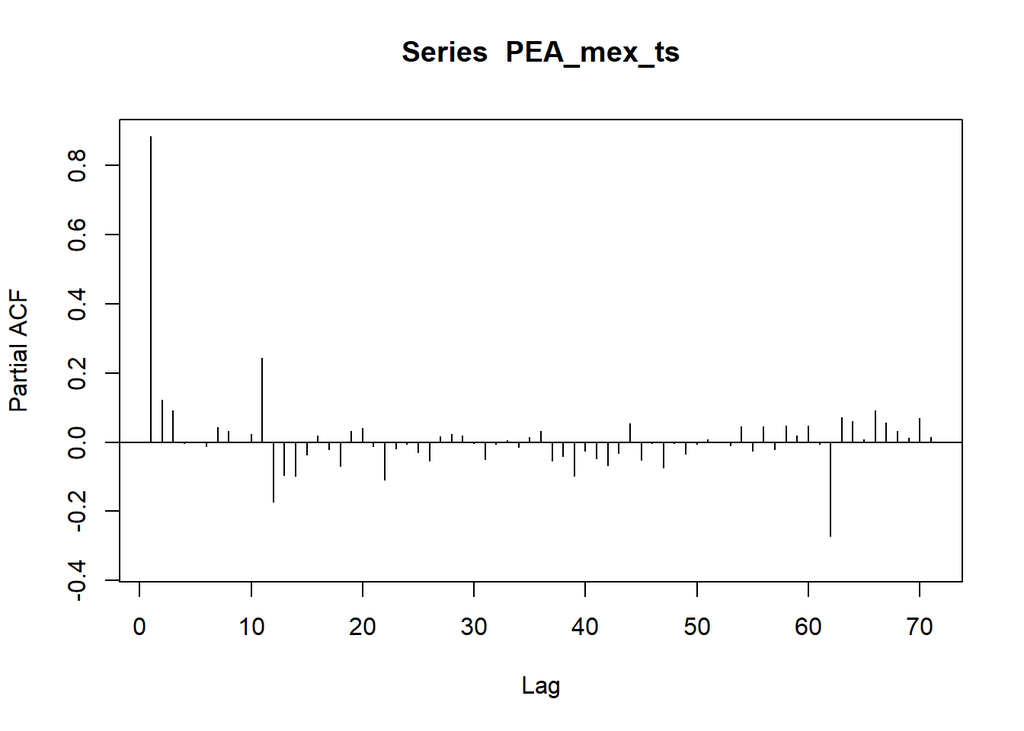

```r
pacf_PEA_mex_ts_sin_diferenciar <- Pacf(PEA_mex_ts, lag.max = 100, ci.type = "ma")
```

```r
head(pacf_PEA_mex_ts_sin_diferenciar)
```

```
##
## Partial autocorrelations of series 'PEA_mex_ts', by lag
##
##      1      2      3      4      5      6
##  0.883  0.122  0.092 -0.003  0.000 -0.011
```

La gráfica de ACF indica que la serie No es una serie estacionaria, para estar 100% seguros heremos un test de Dickey-Fuller

#### Se lleva a cabo el tet de Dickey-Fulley (Ho: Serie no estacionaria) de la Serie 2 (PEA en México)

```r
# Install and load the "urca" package
#install.packages("urca")
library(urca)

# Perform ADF test for stationarity
acf_test_PEA_mex_ts_sin_diferenciar <- ur.df(PEA_mex_ts)

# Print the ADF test results
summary(acf_test_PEA_mex_ts_sin_diferenciar)
```

```
##
## ###############################################
## # Augmented Dickey-Fuller Test Unit Root Test #
## ###############################################
##
## Test regression none
##
##
## Call:
## lm(formula = z.diff ~ z.lag.1 - 1 + z.diff.lag)
##
## Residuals:
##       Min        1Q    Median        3Q       Max
## -10448504   -299654    113676    542175   3805414
##
## Coefficients:
##             Estimate Std. Error t value Pr(>|t|)
## z.lag.1     0.005810   0.003606   1.611  0.11175
## z.diff.lag -0.308664   0.115989  -2.661  0.00971 **
## ---
## Signif. codes:  0 '***' 0.001 '**' 0.01 '*' 0.05 '.' 0.1 ' ' 1
##
## Residual standard error: 1530000 on 68 degrees of freedom
## Multiple R-squared:  0.1113, Adjusted R-squared:  0.08513
## F-statistic: 4.257 on 2 and 68 DF,  p-value: 0.01812
##
##
## Value of test-statistic is: 1.6113
##
## Critical values for test statistics:
##      1pct  5pct 10pct
## tau1 -2.6 -1.95 -1.61
```

Se observa como el valor p de la prueba DF de estacionariedad p> 0.05 por lo tanto NO se rechaza Ho que indica que la serie no es estacionaria.

Para intentar “hacer estacionaria la serie vamos a tomar la primer diferencia de Yt con Yt-1”

#### Vamos a diferenciar la Serie 2 (PEA en México) ‘para hacerlo estacionaria’

```r
# Calculate the difference between consecutive elements
PEA_mex_ts_diferencia1 <- diff(PEA_mex_ts, differences = 1)

# Print the results
print(PEA_mex_ts_diferencia1)
```

```
##         Qtr1      Qtr2      Qtr3      Qtr4
## 1                80586    819771    245315
## 2      60493    305660    819720    149602
## 3    -266106    254507    295531   1004026
## 4    -415756    452725     58161   -210425
## 5     224247    475259   1285426    165203
## 6    -834518   1063858     56900   -711314
## 7      26450    976944    644920    645464
## 8    -579654   1284336    449872   -609051
## 9    -470757   1048623    138488    336533
## 10  -1655557    289276    360177    -87726
## 11   -100890    624641    567602    628675
## 12   -855887    619284    705425   -169731
## 13   -328631    410159    325010    329687
## 14    -95733   1102726    351232    128769
## 15     58958    969312    428411    301783
## 16   -262891 -10036119   6592943   2081649
## 17   -268307   2283121    639192    454347
## 18   -676479   1253105    142052    664985
```

#### ACF & PACF para de la Serie 2 (PEA en México) con diferencia1 ‘estacionariazada’

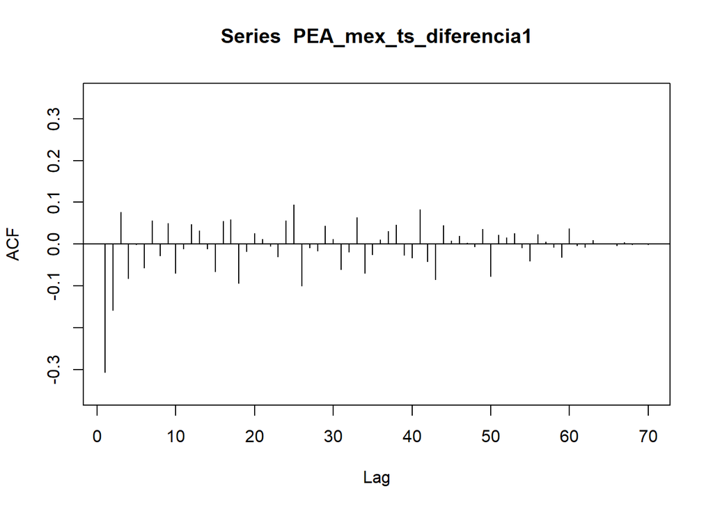

```r
library(forecast)

#par(mfrow=c(2,1))

acf_test_PEA_mex_ts_diferencia1 <- Acf(PEA_mex_ts_diferencia1, lag.max = 100, ci.type = "ma")
```

```r
head(acf_test_PEA_mex_ts_diferencia1)
```

```
##
## Autocorrelations of series 'PEA_mex_ts_diferencia1', by lag
##
##      1      2      3      4      5      6
## -0.307 -0.158  0.076 -0.082  0.000 -0.057
```

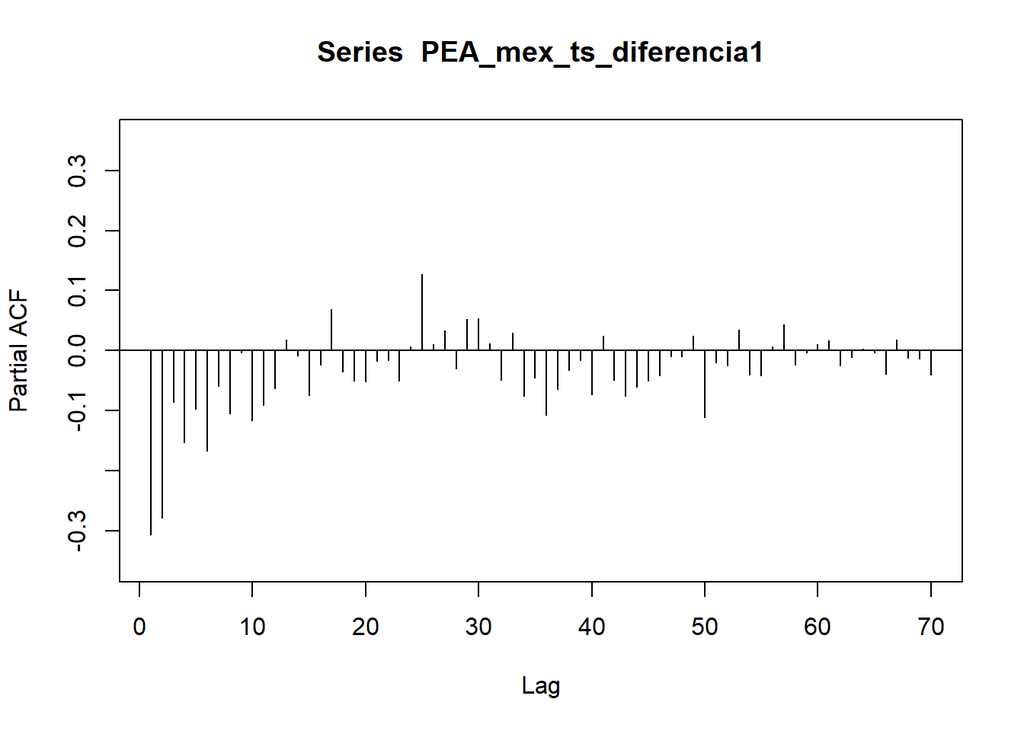

```r
pacf_test_PEA_mex_ts_diferencia1 <- Pacf(PEA_mex_ts_diferencia1, lag.max = 100, ci.type = "ma")
```

```r
head(pacf_test_PEA_mex_ts_diferencia1)
```

```
##
## Partial autocorrelations of series 'PEA_mex_ts_diferencia1', by lag
##
##      1      2      3      4      5      6
## -0.307 -0.279 -0.086 -0.153 -0.098 -0.167
```

Todo indica que la primer diferenciación de la seria ayudó a hacerla estacionaria. Se hace nuevamente una prueba de Dickey-Fulley para verificar estacionariedad

#### Se lleva a cabo el tet de Dickey-Fulley (Ho: Serie no estacionaria) a la Serie 2 (PEA en México) <diferenciar 1>

```r
# Install and load the "urca" package
#install.packages("urca")
library(urca)

# Perform ADF test for stationarity
acf_test_PEA_mex_ts_diferencia1 <- ur.df(PEA_mex_ts_diferencia1)

# Print the ADF test results
summary(acf_test_PEA_mex_ts_diferencia1)
```

```
##
## ###############################################
## # Augmented Dickey-Fuller Test Unit Root Test #
## ###############################################
##
## Test regression none
##
##
## Call:
## lm(formula = z.diff ~ z.lag.1 - 1 + z.diff.lag)
##
## Residuals:
##       Min        1Q    Median        3Q       Max
## -10057002     79499    500746    822809   3092068
##
## Coefficients:
##            Estimate Std. Error t value Pr(>|t|)
## z.lag.1     -1.5723     0.1901  -8.273 7.76e-12 ***
## z.diff.lag   0.2294     0.1188   1.931   0.0577 .
## ---
## Signif. codes:  0 '***' 0.001 '**' 0.01 '*' 0.05 '.' 0.1 ' ' 1
##
## Residual standard error: 1525000 on 67 degrees of freedom
## Multiple R-squared:  0.6587, Adjusted R-squared:  0.6485
## F-statistic: 64.66 on 2 and 67 DF,  p-value: 2.288e-16
##
##
## Value of test-statistic is: -8.2726
##
## Critical values for test statistics:
##      1pct  5pct 10pct
## tau1 -2.6 -1.95 -1.61
```

Con un valor de p<0.05 se comprueba que la serie con 1 diferencia ya es estacionaria.

Con base en las gráficas de ACF y PACF se decide probar un modleo ARIMA (2,1,1)

#### Ajustae y predicicon de para la Serie 2 (PEA en México) con modelo ARIMA

```r
#install.packages("astsa")
library(astsa)

# Fit the SARIMA model
ARIMA_2_1_1_PEA_mex_ts <- astsa::sarima(PEA_mex_ts_train , p=2, d=1, q=1)
```

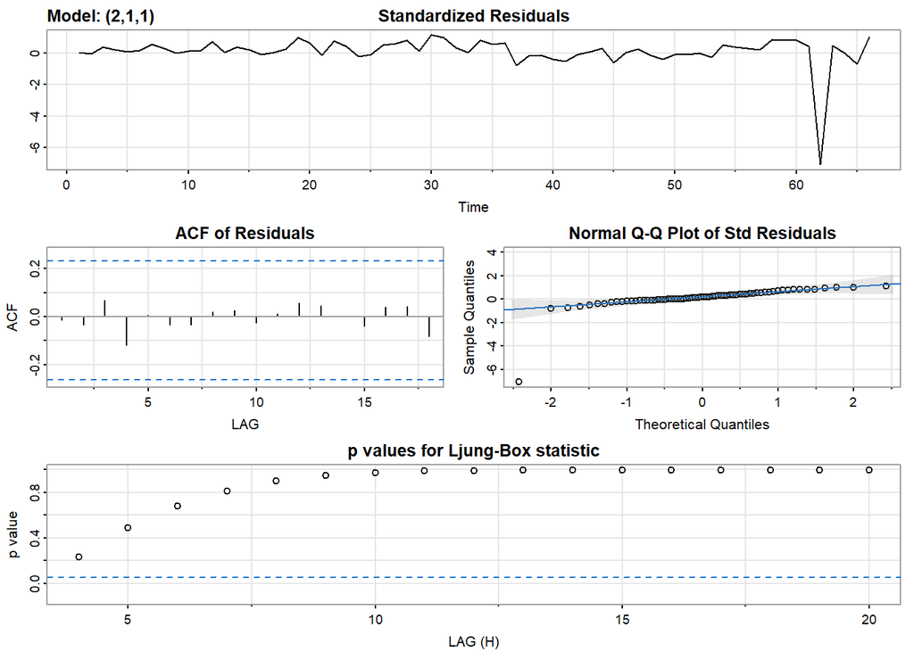

```r
# Print the model summary
summary(ARIMA_2_1_1_PEA_mex_ts)
```

```
##                    Length Class  Mode
## fit                14     Arima  list
## degrees_of_freedom  1     -none- numeric
## ttable             16     -none- numeric
## AIC                 1     -none- numeric
## AICc                1     -none- numeric
## BIC                 1     -none- numeric
```

En general se observa para el modelo ARIMA_2_1_1_PEA_mex_ts:

Los errores estandarizados tienen un compartiempo aprorximadamente normal con media cero Los errores estandarizados no tiene una correlación signifcativa

#### Calculo de predicción del ARIMA para la Serie 2 (PEA en México)

```r
# Get the predictors


pred_ARIMA_2_1_1_PEA_mex_ts <- sarima.for(PEA_mex_ts_train, n.ahead=6,2,1,1)
```

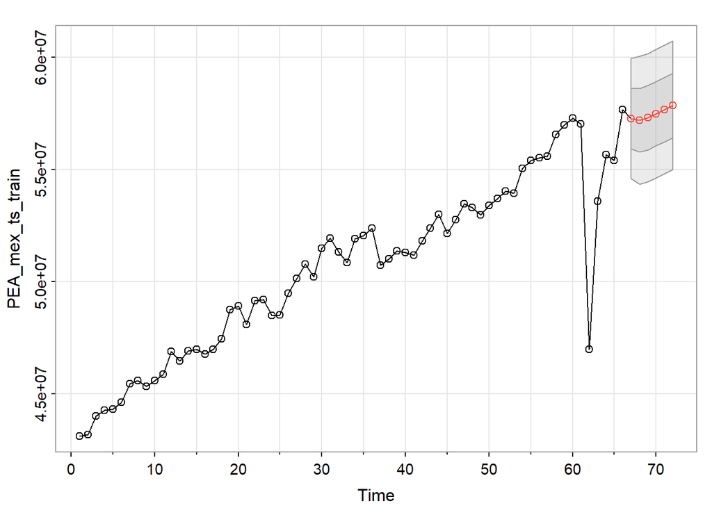

```r
pred_ARIMA_2_1_1_PEA_mex_ts
```

```
## $pred
## Time Series:
## Start = 67
## End = 72
## Frequency = 1
## [1] 57261741 57190145 57305915 57477593 57663628 57853143
##
## $se
## Time Series:
## Start = 67
## End = 72
## Frequency = 1
## [1] 1339489 1423802 1431565 1432507 1432674 1432710
```

```r
pred_ARIMA_2_1_1_PEA_mex_ts$pred
```

```
## Time Series:
## Start = 67
## End = 72
## Frequency = 1
## [1] 57261741 57190145 57305915 57477593 57663628 57853143
```

#### Calculo de errores del modelo ARIMA para la Serie 2 (PEA en México)

```r
accuracy(PEA_mex_ts_test ,pred_ARIMA_2_1_1_PEA_mex_ts$pred )
```

```
##                ME    RMSE     MAE      MPE    MAPE       ACF1 Theil's U
## Test set -1561122 1642627 1561122 -2.71415 2.71415 0.01000987  11.28419
```

El MAPE del modelo ARIMA 2,1,1 para la Serie 2 (PEA en México) es de 2.71%

#### Ajustae y predicicon con modelo SARIMA para la Serie 2 (PEA en México)

```r
#install.packages("astsa")
library(astsa)

# Fit the SARIMA model
SARIMA_PEA_mex_ts <- Arima(PEA_mex_ts_train, order = c(2, 1, 1), seasonal = list(order = c(0, 1, 0), period = 4))

# Print the model summary
summary(SARIMA_PEA_mex_ts)
```

```
## Series: PEA_mex_ts_train
## ARIMA(2,1,1)(0,1,0)[4]
##
## Coefficients:
##           ar1      ar2     ma1
##       -1.2838  -0.6199  1.0000
## s.e.   0.1369   0.1545  0.1194
##
## sigma^2 = 4.1e+12:  log likelihood = -972.75
## AIC=1953.5   AICc=1954.22   BIC=1961.95
##
## Training set error measures:
##                    ME    RMSE      MAE        MPE     MAPE     MASE      ACF1
## Training set 86214.68 1898142 794980.1 0.08991677 1.553944 1.023515 0.1100818
```

#### Calculo de predicción del SARIMA para la Serie 2 (PEA en México)

```r
# Get the predictors


pred_SARIMA_PEA_mex_ts <- forecast(SARIMA_PEA_mex_ts, h = 6)
pred_SARIMA_PEA_mex_ts
```

```
##    Point Forecast    Lo 80    Hi 80    Lo 95    Hi 95
## 67       55928936 53313271 58544602 51928621 59929251
## 68       61070971 57877821 64264120 56187470 65954471
## 69       62038822 58621763 65455882 56812881 67264764
## 70       60837863 56608501 65067225 54369613 67306113
## 71       62805124 57084723 68525525 54056525 71553722
## 72       65348399 58430779 72266019 54768812 75927986
```

```r
pred_SARIMA_PEA_mex_ts$mean
```

```
## Time Series:
## Start = 67
## End = 72
## Frequency = 1
## [1] 55928936 61070971 62038822 60837863 62805124 65348399
```

#### Calculo de errores del modelo SARIMA para la Serie 2 (PEA en México)

```r
accuracy(PEA_mex_ts_test ,pred_SARIMA_PEA_mex_ts$mean )
```

```
##               ME    RMSE     MAE      MPE     MAPE       ACF1 Theil's U
## Test set 2318536 3341459 3111373 3.603525 5.021103 0.02209113  1.178148
```

# Serie de tiempo 3 CON tendencia y CON estacionalidad (Historico mensual de Demanda de Gas Natural para el sector eléctrico en México)

Primero importamos la data con el gas demandado en el sector electrico

```r
Demanda_electrico_importado<-read.csv("Demanda_electrico_2022_full1.csv", header= TRUE)
```

Nos aseguramos que la data con el gas demandado en el sector electrico se haya importado correctamente

```r
head(Demanda_electrico_importado)
```

```
##       Date Demanded_Gas
## 1 1/1/2005      1819.58
## 2 2/1/2005      1895.33
## 3 3/1/2005      1765.86
## 4 4/1/2005      1642.70
## 5 5/1/2005      1895.54
## 6 6/1/2005      2051.72
```

```r
summary(Demanda_electrico_importado)
```

```
##      Date            Demanded_Gas
##  Length:213         Min.   :1561
##  Class :character   1st Qu.:2600
##  Mode  :character   Median :3016
##                     Mean   :3038
##                     3rd Qu.:3403
##                     Max.   :5168
```

```r
typeof(Demanda_electrico_importado)
```

```
## [1] "list"
```

```r
dim(Demanda_electrico_importado)
```

```
## [1] 213   2
```

Transformamos el tipo de dato de la columna DATE a as.date column

```r
Demanda_electrico_importado$Date <- as.Date(Demanda_electrico_importado$Date, format = "%m/%d/%Y")
head(Demanda_electrico_importado)
```

```
##         Date Demanded_Gas
## 1 2005-01-01      1819.58
## 2 2005-02-01      1895.33
## 3 2005-03-01      1765.86
## 4 2005-04-01      1642.70
## 5 2005-05-01      1895.54
## 6 2005-06-01      2051.72
```

```r
tail(Demanda_electrico_importado)
```

```
##           Date Demanded_Gas
## 208 2022-04-01      3403.44
## 209 2022-05-01      3350.03
## 210 2022-06-01      3498.70
## 211 2022-07-01      3350.97
## 212 2022-08-01      3506.42
## 213 2022-09-01      3778.37
```

```r
typeof(Demanda_electrico_importado)
```

```
## [1] "list"
```

```r
Demanda_electrico_importado
```

```
##           Date Demanded_Gas
## 1   2005-01-01      1819.58
## 2   2005-02-01      1895.33
## 3   2005-03-01      1765.86
## 4   2005-04-01      1642.70
## 5   2005-05-01      1895.54
## 6   2005-06-01      2051.72
## 7   2005-07-01      1962.05
## 8   2005-08-01      1889.66
## 9   2005-09-01      1739.10
## 10  2005-10-01      1695.92
## 11  2005-11-01      1648.95
## 12  2005-12-01      1560.98
## 13  2006-01-01      1610.45
## 14  2006-02-01      1806.33
```

[output cut: 199 more lines]

#### Convertimos los data importada a Serie de tiempo

```r
Demanda_electrico_ts<- ts(Demanda_electrico_importado$Demanded_Gas, frequency = 12)
head(Demanda_electrico_ts)
```

```
##       Jan     Feb     Mar     Apr     May     Jun
## 1 1819.58 1895.33 1765.86 1642.70 1895.54 2051.72
```

```r
typeof(Demanda_electrico_ts)
```

```
## [1] "double"
```

Graficamos la serie del tiempo

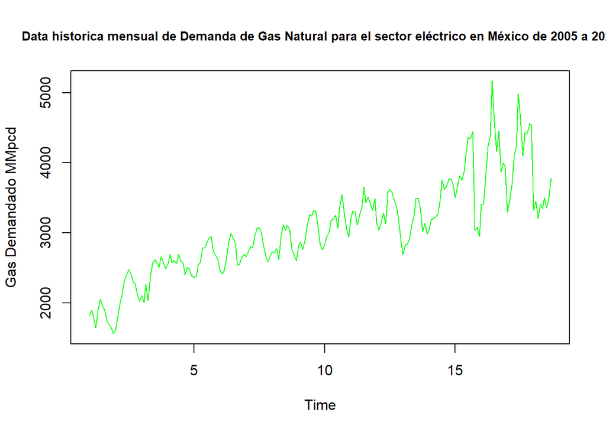

```r
plot(Demanda_electrico_ts, col = "green", main = "Data historica mensual de Demanda de Gas Natural para el sector eléctrico en México de 2005 a 2022", cex.main=0.85, ylab="Gas Demandado MMpcd")
```

### Vamos a descomponer la data usando el metodo decompose para entender sus componentes de tren, seasonalidad y aleatorio de la Serie 3 (Demanda de Gas Natural en sector eléctrico en México)

```r
Demanda_electrico_ts_decompose <- decompose(Demanda_electrico_ts)
summary(Demanda_electrico_ts_decompose)
```

```
##          Length Class  Mode
## x        213    ts     numeric
## seasonal 213    ts     numeric
## trend    213    ts     numeric
## random   213    ts     numeric
## figure    12    -none- numeric
## type       1    -none- character
```

Vamos a plotear la desmposición

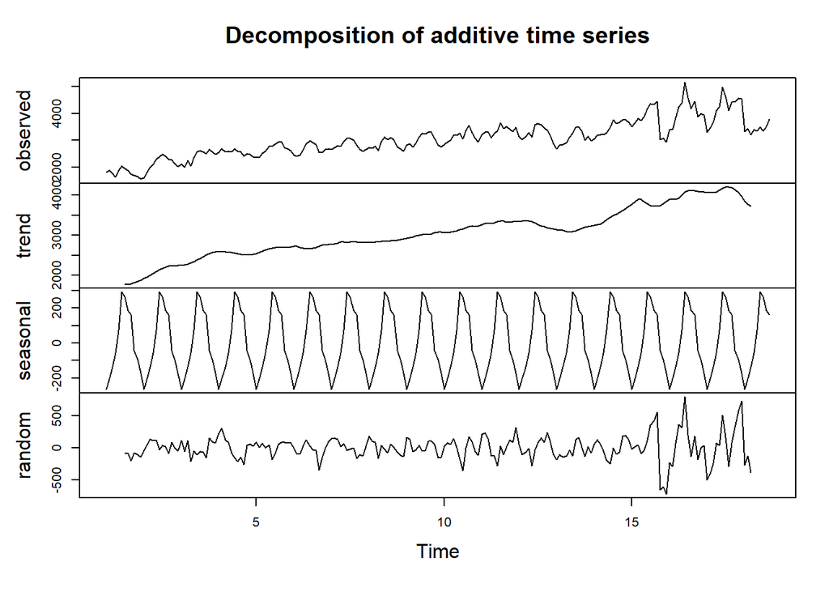

```r
plot(Demanda_electrico_ts_decompose)
```

Se observa claramente una tendencia creciente (excepto en años 2020 y 2021 derivado de pandemia de Covid-19). Se observa una estacionalidad en donde hay una “subida los primeros 6 meses”, se llega asu máximo en el mes 07-08 y una bajada los meses 09, 10 y 11.

### Analicemos los valores de la variable Y

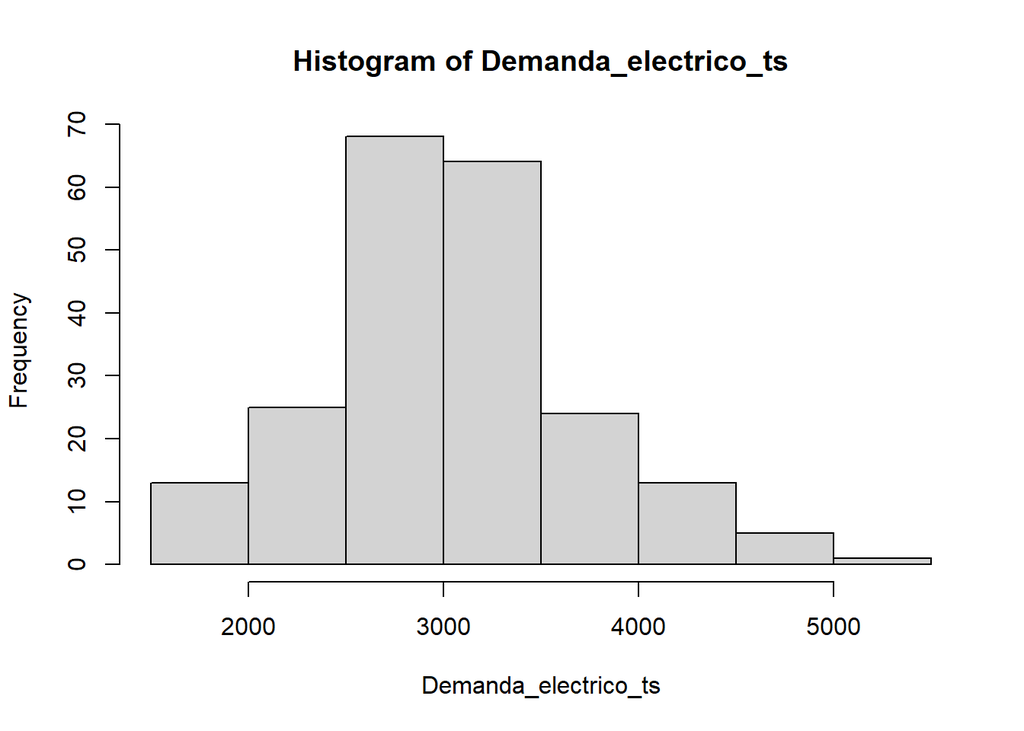

```r
hist(Demanda_electrico_ts)
```

```r
summary(Demanda_electrico_ts)
```

```
##    Min. 1st Qu.  Median    Mean 3rd Qu.    Max.
##    1561    2600    3016    3038    3403    5168
```

```r
library(e1071)

# Calculate skewness
skewness_value_serie_Demanda_electrico <- skewness(Demanda_electrico_ts)

# Calculate kurtosis
kurtosis_value_serie_Demanda_electrico <- kurtosis(Demanda_electrico_ts)

# Print the results
print(paste("Skewness:", skewness_value_serie_Demanda_electrico))
```

```
## [1] "Skewness: 0.37246820224812"
```

```r
print(paste("Kurtosis:", kurtosis_value_serie_Demanda_electrico))
```

```
## [1] "Kurtosis: 0.259274145723206"
```

Se observa que la gran mayoria de los valores de la variable y están en el intervalo de [2,500 - 3,500 Mpcd] y que la variable puede seguir una distribución ’Aproximadamente normal con una ligera “skewness” hacia la cola derecha

#### Separamos training and testing sets DE LA SERIE 3 (Demanda_electrico) para aplicar modeo ARIMA & SARIMA

```r
# Split the data into training and testing sets


# Subset the data to keep rows from the beginning until train_end and all columns
Demanda_electrico_original_train <- Demanda_electrico_ts[1:201]
head(Demanda_electrico_original_train)
```

```
## [1] 1819.58 1895.33 1765.86 1642.70 1895.54 2051.72
```

```r
# Subset the data to keep rows from the beginning until train_end and all columns


Demanda_electrico_original_test <- Demanda_electrico_ts[202:213]
Demanda_electrico_original_test
```

```
##  [1] 4417.51 4557.36 4538.89 3320.75 3449.80 3206.96 3403.44 3350.03 3498.70
## [10] 3350.97 3506.42 3778.37
```

## Modelo SARIMA para Serie 3 (Demanda_electrico México)

#### Determinación de ACF & PACF para el caso de la Serie 3 (Demanda_electrico México) sin diferneciar

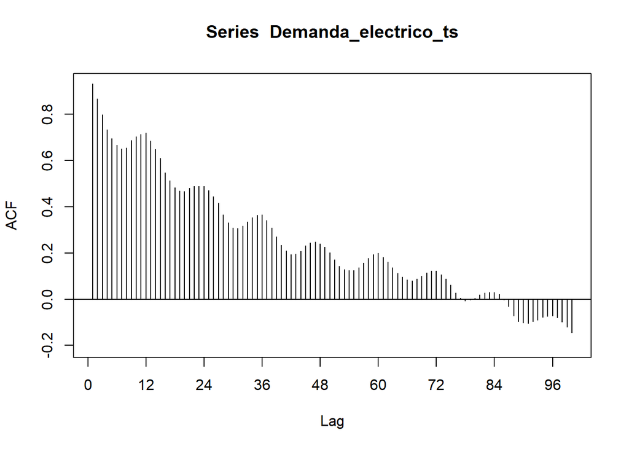

```r
#install.packages("forecast")
library(forecast)

#par(mfrow=c(2,1))

acf_Demanda_electrico_ts_sin_diferenciar <- Acf(Demanda_electrico_ts, lag.max = 100, ci.type = "ma")
```

```r
acf_Demanda_electrico_ts_sin_diferenciar
```

```
##
## Autocorrelations of series 'Demanda_electrico_ts', by lag
##
##      0      1      2      3      4      5      6      7      8      9     10
##  1.000  0.931  0.866  0.798  0.733  0.695  0.665  0.649  0.655  0.686  0.704
##     11     12     13     14     15     16     17     18     19     20     21
##  0.713  0.719  0.684  0.648  0.609  0.548  0.514  0.483  0.468  0.467  0.481
##     22     23     24     25     26     27     28     29     30     31     32
##  0.489  0.488  0.489  0.469  0.444  0.416  0.364  0.331  0.309  0.307  0.317
##     33     34     35     36     37     38     39     40     41     42     43
##  0.335  0.354  0.363  0.364  0.340  0.309  0.270  0.234  0.210  0.194  0.196
##     44     45     46     47     48     49     50     51     52     53     54
##  0.208  0.231  0.245  0.247  0.241  0.225  0.201  0.172  0.143  0.128  0.124
##     55     56     57     58     59     60     61     62     63     64     65
##  0.125  0.136  0.158  0.177  0.193  0.199  0.181  0.160  0.137  0.113  0.095
##     66     67     68     69     70     71     72     73     74     75     76
##  0.084  0.080  0.088  0.100  0.114  0.122  0.123  0.107  0.088  0.061  0.028
##     77     78     79     80     81     82     83     84     85     86     87
##  0.005 -0.007 -0.003  0.006  0.020  0.027  0.029  0.029  0.020 -0.002 -0.032
##     88     89     90     91     92     93     94     95     96     97     98
## -0.072 -0.096 -0.103 -0.104 -0.096 -0.090 -0.078 -0.073 -0.071 -0.080 -0.098
##     99    100
## -0.119 -0.145
```

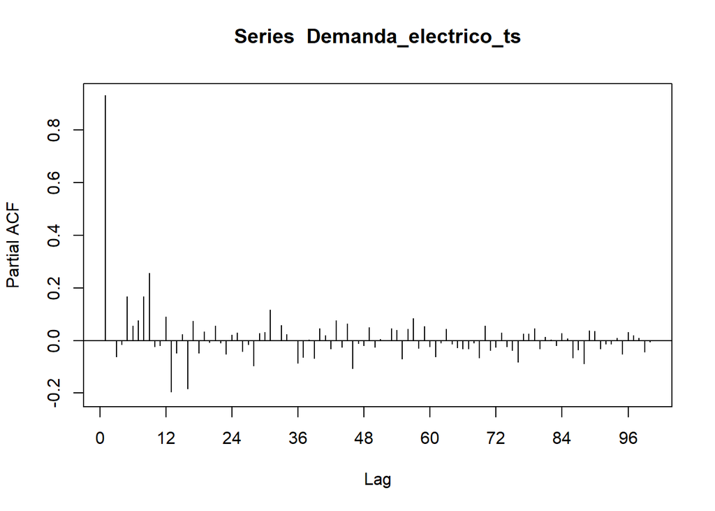

```r
pacf_Demanda_electrico_ts_sin_diferenciar <- Pacf(Demanda_electrico_ts, lag.max = 100, ci.type = "ma")
```

```r
pacf_Demanda_electrico_ts_sin_diferenciar
```

```
##
## Partial autocorrelations of series 'Demanda_electrico_ts', by lag
##
##      1      2      3      4      5      6      7      8      9     10     11
##  0.931  0.002 -0.062 -0.016  0.167  0.056  0.076  0.167  0.257 -0.024 -0.019
##     12     13     14     15     16     17     18     19     20     21     22
##  0.091 -0.195 -0.048  0.023 -0.183  0.073 -0.047  0.033 -0.008  0.055 -0.008
##     23     24     25     26     27     28     29     30     31     32     33
## -0.051  0.022  0.029 -0.042 -0.015 -0.096  0.028  0.032  0.116  0.000  0.059
##     34     35     36     37     38     39     40     41     42     43     44
##  0.023 -0.002 -0.085 -0.064  0.004 -0.068  0.045  0.020 -0.031  0.076 -0.025
##     45     46     47     48     49     50     51     52     53     54     55
##  0.064 -0.106 -0.010 -0.019  0.050 -0.026  0.005  0.000  0.045  0.039 -0.070
##     56     57     58     59     60     61     62     63     64     65     66
##  0.043  0.083 -0.029  0.054 -0.022 -0.062 -0.010  0.043 -0.012 -0.026 -0.032
##     67     68     69     70     71     72     73     74     75     76     77
## -0.031 -0.009 -0.065  0.055 -0.038 -0.025  0.030 -0.022 -0.038 -0.082  0.026
##     78     79     80     81     82     83     84     85     86     87     88
##  0.024  0.045 -0.031  0.012  0.002 -0.020  0.027  0.007 -0.065 -0.035 -0.088
##     89     90     91     92     93     94     95     96     97     98     99
##  0.038  0.035 -0.031 -0.014 -0.014  0.010 -0.051  0.031  0.019  0.009 -0.043
##    100
## -0.005
```

La gráfica de ACF indica claramente que la serie No es una serie estacionaria, para estar 100% seguros heremos un test de Dickey-Fuller

#### Se lleva a cabo el tet de Dickey-Fulley (Ho: Serie no estacionaria) de la Serie 3 (Demanda_electrico México)

```r
# Install and load the "urca" package
#install.packages("urca")
library(urca)

# Perform ADF test for stationarity
acf_test_Demanda_electrico_ts_sin_diferenciar <- ur.df(Demanda_electrico_ts)

# Print the ADF test results
summary(acf_test_Demanda_electrico_ts_sin_diferenciar)
```

```
##
## ###############################################
## # Augmented Dickey-Fuller Test Unit Root Test #
## ###############################################
##
## Test regression none
##
##
## Call:
## lm(formula = z.diff ~ z.lag.1 - 1 + z.diff.lag)
##
## Residuals:
##      Min       1Q   Median       3Q      Max
## -1405.56   -92.09    19.79   140.66   783.52
##
## Coefficients:
##              Estimate Std. Error t value Pr(>|t|)
## z.lag.1    -0.0001106  0.0051949  -0.021    0.983
## z.diff.lag -0.0175182  0.0695219  -0.252    0.801
##
## Residual standard error: 234.5 on 209 degrees of freedom
## Multiple R-squared:  0.0003107,  Adjusted R-squared:  -0.009256
## F-statistic: 0.03248 on 2 and 209 DF,  p-value: 0.968
##
##
## Value of test-statistic is: -0.0213
##
## Critical values for test statistics:
##       1pct  5pct 10pct
## tau1 -2.58 -1.95 -1.62
```

Se observa como el valor p de la prueba DF de estacionariedad p> 0.05 por lo tanto NO se rechaza Ho que indica que la serie no es estacionaria.

Para intentar “hacer estacionaria la serie vamos a tomar la primer diferencia de Yt con Yt-1”

#### Vamos a diferenciar la Serie 3 (Demanda_electrico México) ‘para hacerlo estacionaria’

```r
# Calculate the difference between consecutive elements
Demanda_electrico_ts_diferencia1 <- diff(Demanda_electrico_ts, differences = 1)

# Print the results
head(Demanda_electrico_ts_diferencia1)
```

```
##       Feb     Mar     Apr     May     Jun     Jul
## 1   75.75 -129.47 -123.16  252.84  156.18  -89.67
```

#### ACF & PACF para de la Serie 3 (Demanda_electrico México) con diferencia1 ‘estacionariazada’

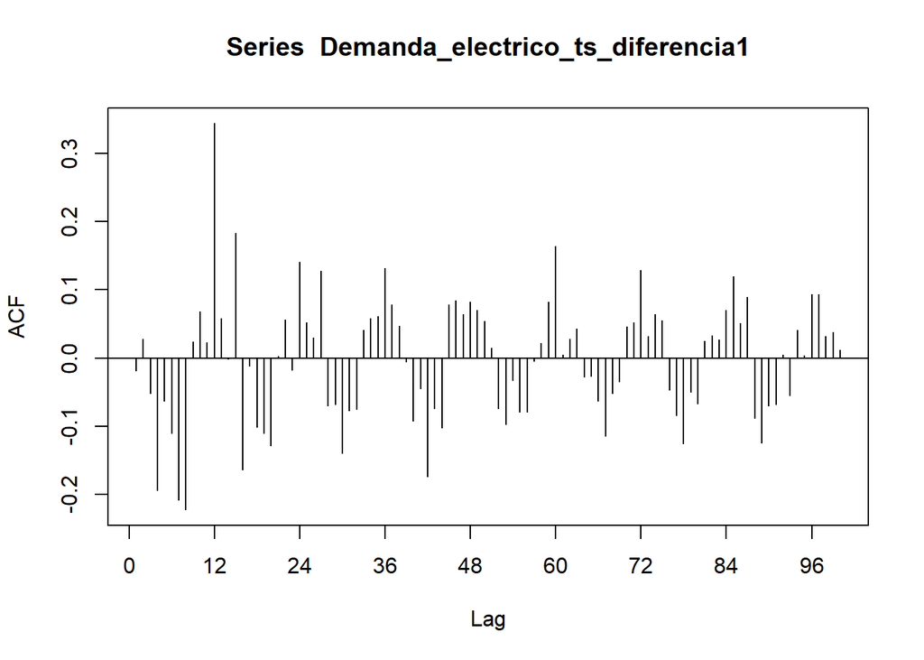

```r
library(forecast)

#par(mfrow=c(2,1))

acf_test_Demanda_electrico_ts_diferencia1 <- Acf(Demanda_electrico_ts_diferencia1, lag.max = 100, ci.type = "ma")
```

```r
head(acf_test_Demanda_electrico_ts_diferencia1)
```

```
##
## Autocorrelations of series 'Demanda_electrico_ts_diferencia1', by lag
##
##      1      2      3      4      5      6
## -0.019  0.028 -0.051 -0.194 -0.063 -0.111
```

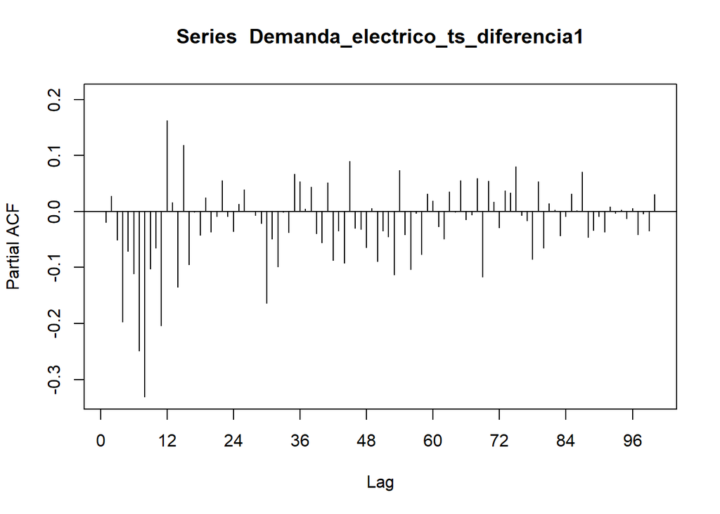

```r
pacf_test_Demanda_electrico_ts_diferencia1 <- Pacf(Demanda_electrico_ts_diferencia1, lag.max = 100, ci.type = "ma")
```

```r
head(pacf_test_Demanda_electrico_ts_diferencia1)
```

```
##
## Partial autocorrelations of series 'Demanda_electrico_ts_diferencia1', by lag
##
##      1      2      3      4      5      6
## -0.019  0.028 -0.050 -0.197 -0.071 -0.112
```

Todo indica que la primer diferenciación de la seria ayudó a hacerla estacionaria. Se hace nuevamente una prueba de Dickey-Fulley para verificar estacionariedad

#### Se lleva a cabo el tet de Dickey-Fulley (Ho: Serie no estacionaria) a la Serie 3 (Demanda_electrico México) <diferenciar 1>

```r
# Install and load the "urca" package
#install.packages("urca")
library(urca)

# Perform ADF test for stationarity
acf_test_Demanda_electrico_ts_diferencia1 <- ur.df(Demanda_electrico_ts_diferencia1)

# Print the ADF test results
summary(acf_test_Demanda_electrico_ts_diferencia1)
```

```
##
## ###############################################
## # Augmented Dickey-Fuller Test Unit Root Test #
## ###############################################
##
## Test regression none
##
##
## Call:
## lm(formula = z.diff ~ z.lag.1 - 1 + z.diff.lag)
##
## Residuals:
##      Min       1Q   Median       3Q      Max
## -1405.65   -90.43    17.76   138.67   770.60
##
## Coefficients:
##            Estimate Std. Error t value Pr(>|t|)
## z.lag.1    -0.98675    0.09935  -9.932   <2e-16 ***
## z.diff.lag -0.02939    0.06954  -0.423    0.673
## ---
## Signif. codes:  0 '***' 0.001 '**' 0.01 '*' 0.05 '.' 0.1 ' ' 1
##
## Residual standard error: 234.8 on 208 degrees of freedom
## Multiple R-squared:  0.5076, Adjusted R-squared:  0.5028
## F-statistic: 107.2 on 2 and 208 DF,  p-value: < 2.2e-16
##
##
## Value of test-statistic is: -9.9318
##
## Critical values for test statistics:
##       1pct  5pct 10pct
## tau1 -2.58 -1.95 -1.62
```

Con un valor de p<0.05 se comprueba que la serie con 1 diferencia ya es estacionaria.

Con base en las gráficas de ACF y PACF se decide probar un modleo ARIMA (1,1,1)

#### Ajuste y predicicon de para la serie 3 (Demanda_electrico México) con modelo ARIMA

```r
#install.packages("astsa")
library(astsa)

# Fit the SARIMA model
ARIMA_1_1_1_Demanda_electrico_original_ts <- astsa::sarima(Demanda_electrico_original_train , p=1, d=1, q=1)
```

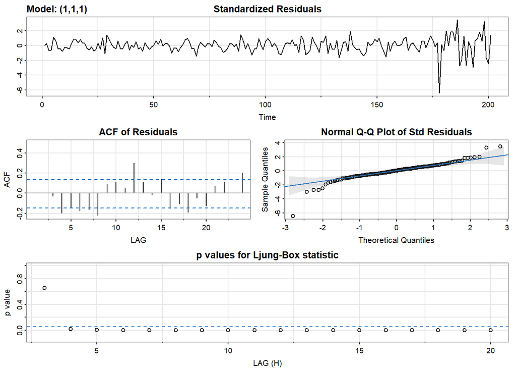

```r
# Print the model summary
summary(ARIMA_1_1_1_Demanda_electrico_original_ts)
```

```
##                    Length Class  Mode
## fit                14     Arima  list
## degrees_of_freedom  1     -none- numeric
## ttable             12     -none- numeric
## AIC                 1     -none- numeric
## AICc                1     -none- numeric
## BIC                 1     -none- numeric
```

#### Calculo de predicción del ARIMA para la serie 3 (Demanda_electrico México)

```r
# Get the predictors


pred_ARIMA_1_1_1_Demanda_electrico_original_ts <- sarima.for(Demanda_electrico_original_train, n.ahead=12,1,1,1)
```

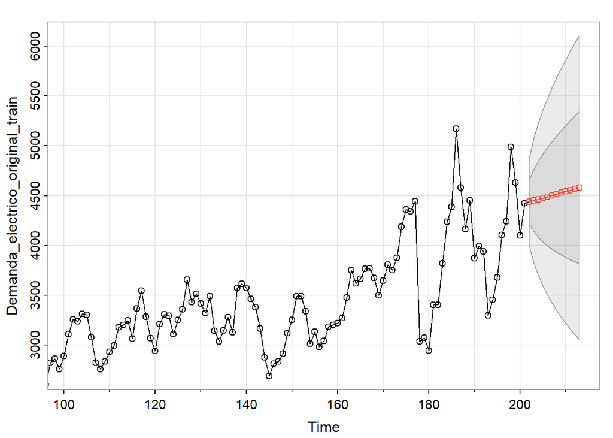

```r
pred_ARIMA_1_1_1_Demanda_electrico_original_ts
```

```
## $pred
## Time Series:
## Start = 202
## End = 213
## Frequency = 1
##  [1] 4437.340 4450.379 4463.400 4476.424 4489.448 4502.472 4515.496 4528.520
##  [9] 4541.544 4554.568 4567.592 4580.616
##
## $se
## Time Series:
## Start = 202
## End = 213
## Frequency = 1
##  [1] 220.2614 311.4680 381.4619 440.4694 492.4566 539.4569 582.6783 622.9079
##  [9] 660.6924 696.4299 730.4210 762.8992
```

```r
pred_ARIMA_1_1_1_Demanda_electrico_original_ts$pred
```

```
## Time Series:
## Start = 202
## End = 213
## Frequency = 1
##  [1] 4437.340 4450.379 4463.400 4476.424 4489.448 4502.472 4515.496 4528.520
##  [9] 4541.544 4554.568 4567.592 4580.616
```

#### Calculo de errores del modelo ARIMA para la serie 3 (Demanda_electrico México)

```r
accuracy(Demanda_electrico_original_test ,pred_ARIMA_1_1_1_Demanda_electrico_original_ts$pred)
```

```
##                ME     RMSE      MAE      MPE     MAPE      ACF1 Theil's U
## Test set 810.7165 959.3271 841.1284 17.90716 18.58969 0.6187345  76.76691
```

#### Ajustae y predicicon de Demanda_electrico con modelo SARIMA + PDQ S

```r
library(forecast)


# Fit the SARIMA model
SARIMA_PDQS_Demanda_electrico_V1_model <- Arima(Demanda_electrico_original_train, order = c(1, 1, 1), seasonal = list(order = c(0, 1, 1), period = 12))

# Forecast for the next 12 periods
forecast_SARIMA_PDQS_Demanda_electrico_V1_model <- forecast(SARIMA_PDQS_Demanda_electrico_V1_model, h = 12)

# Print the forecasted values
print(forecast_SARIMA_PDQS_Demanda_electrico_V1_model)
```

```
##     Point Forecast    Lo 80    Hi 80    Lo 95    Hi 95
## 202       3859.661 3618.270 4101.051 3490.485 4228.836
## 203       3885.930 3586.639 4185.221 3428.204 4343.656
## 204       3786.329 3459.982 4112.675 3287.225 4285.433
## 205       3631.487 3291.293 3971.680 3111.205 4151.768
## 206       3726.556 3378.968 4074.144 3194.966 4258.146
## 207       3927.394 3575.743 4279.045 3389.591 4465.197
## 208       4165.204 3811.267 4519.141 3623.904 4706.505
## 209       4288.359 3933.104 4643.615 3745.043 4831.675
## 210       4815.804 4459.771 5171.838 4271.298 5360.310
## 211       4638.281 4281.776 4994.786 4093.053 5183.509
## 212       4347.246 3990.447 4704.044 3801.569 4892.922
## 213       4528.376 4171.389 4885.362 3982.412 5074.340
```

```r
forecast_SARIMA_PDQS_Demanda_electrico_V1_model$mean
```

```
## Time Series:
## Start = 202
## End = 213
## Frequency = 1
##  [1] 3859.661 3885.930 3786.329 3631.487 3726.556 3927.394 4165.204 4288.359
##  [9] 4815.804 4638.281 4347.246 4528.376
```

#### Calculo de errores del Demanda_electrico_original.ts con SARIMA + PDQ S

```r
accuracy(Demanda_electrico_original_test ,forecast_SARIMA_PDQS_Demanda_electrico_V1_model$mean )
```

```
##                ME     RMSE      MAE    MPE     MAPE      ACF1 Theil's U
## Test set 435.1189 823.7472 765.4256 9.4914 18.09266 0.7599917  3.646969
```

## Estrategia de limitación del set de train serie 3 (Demanda electrico) (Con data de entrenameitno hatsa 1:170 que es ignorar 2021 y 2021)

#### Training and testing sets (ORIGINAL) para aplicar modeo ARIMA serie 3 (Demanda electrico) (Con data de entrenameitno hatsa 1:170 que es ignorar 2021 y 2021)

```r
# Split the data into training and testing sets


# Subset the data to keep rows from the beginning until train_end and all columns
Demanda_electrico_train_V2 <- Demanda_electrico_ts[1:170]
head(Demanda_electrico_train_V2)
```

```
## [1] 1819.58 1895.33 1765.86 1642.70 1895.54 2051.72
```

```r
tail(Demanda_electrico_train_V2)
```

```
## [1] 3664.34 3765.69 3772.25 3676.41 3500.08 3647.60
```

```r
# Subset the data to keep rows from the beginning until train_end and all columns


Demanda_electrico_test_V2 <- Demanda_electrico_ts[202:213]
Demanda_electrico_test_V2
```

```
##  [1] 4417.51 4557.36 4538.89 3320.75 3449.80 3206.96 3403.44 3350.03 3498.70
## [10] 3350.97 3506.42 3778.37
```

```r
#install.packages("astsa")
library(astsa)

# Fit the SARIMA model
ARIMA_1_1_1_Demanda_electrico_V2 <- astsa::sarima( Demanda_electrico_train_V2 , p=1, d=1, q=1)
```

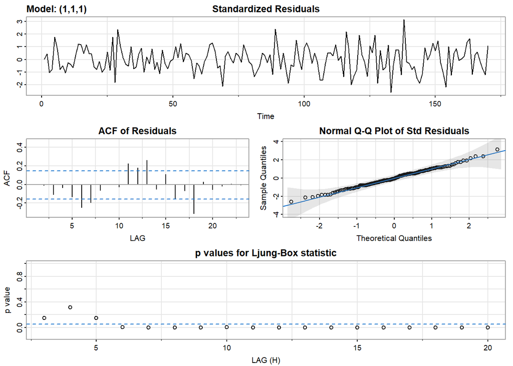

```r
# Print the model summary
summary(ARIMA_1_1_1_Demanda_electrico_V2)
```

```
##                    Length Class  Mode
## fit                14     Arima  list
## degrees_of_freedom  1     -none- numeric
## ttable             12     -none- numeric
## AIC                 1     -none- numeric
## AICc                1     -none- numeric
## BIC                 1     -none- numeric
```

```r
# Get the predictors


pred_ARIMA_1_1_1_Demanda_electrico_V2 <- sarima.for(Demanda_electrico_train_V2, n.ahead=12,1,1,1)
```

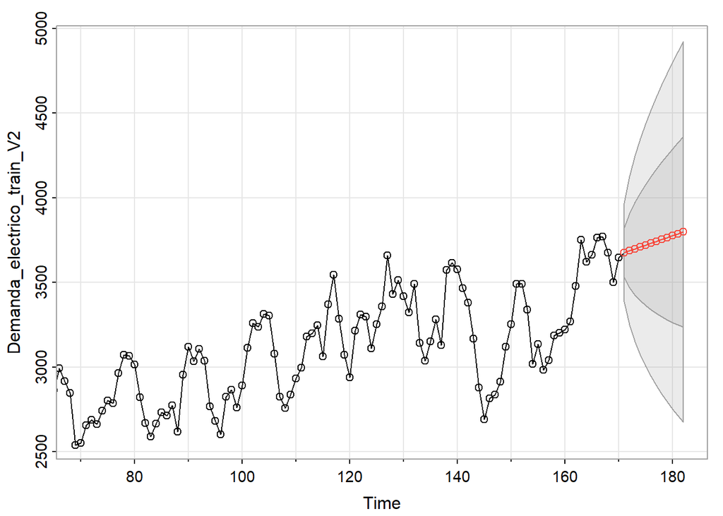

```r
pred_ARIMA_1_1_1_Demanda_electrico_V2
```

```
## $pred
## Time Series:
## Start = 171
## End = 182
## Frequency = 1
##  [1] 3677.316 3688.705 3699.704 3710.695 3721.686 3732.677 3743.668 3754.658
##  [9] 3765.649 3776.640 3787.631 3798.621
##
## $se
## Time Series:
## Start = 171
## End = 182
## Frequency = 1
##  [1] 145.6214 218.7991 273.2466 318.5231 358.1205 393.7558 426.4235 456.7607
##  [9] 485.2047 512.0713 537.5968 561.9641
```

```r
pred_ARIMA_1_1_1_Demanda_electrico_V2$pred
```

```
## Time Series:
## Start = 171
## End = 182
## Frequency = 1
##  [1] 3677.316 3688.705 3699.704 3710.695 3721.686 3732.677 3743.668 3754.658
##  [9] 3765.649 3776.640 3787.631 3798.621
```

#### Calculo de errores de serie 3 (Demanda electrico) con modleo (Con data de entrenameitno hatsa 1:170 que es ignorar 2021 y 2021)

```r
accuracy(Demanda_electrico_original_test ,pred_ARIMA_1_1_1_Demanda_electrico_V2$pred )
```

```
##                ME     RMSE      MAE       MPE     MAPE      ACF1 Theil's U
## Test set 39.87085 509.9399 447.8766 0.9767206 12.03676 0.6151629  44.16447
```

### Ajustae y predicicon de Demanda_electrico con modelo SARIMA + PDQ S

```r
library(forecast)


# Fit the SARIMA model
SARIMA_PDQS_Demanda_electrico_V2_model <- Arima(Demanda_electrico_train_V2, order = c(1, 1, 1), seasonal = list(order = c(1, 1, 1), period = 12))

# Forecast for the next 12 periods
forecast_SARIMA_PDQS_Demanda_electrico_V2_model<- forecast(SARIMA_PDQS_Demanda_electrico_V2_model, h = 12)

# Print the forecasted values
print(forecast_SARIMA_PDQS_Demanda_electrico_V2_model)
```

```
##     Point Forecast    Lo 80    Hi 80    Lo 95    Hi 95
## 171       3631.668 3464.376 3798.959 3375.817 3887.518
## 172       3616.936 3402.196 3831.677 3288.519 3945.353
## 173       3715.439 3473.906 3956.971 3346.047 4084.831
## 174       3858.029 3599.275 4116.782 3462.299 4253.758
## 175       3913.764 3643.001 4184.527 3499.668 4327.860
## 176       3884.192 3604.500 4163.884 3456.440 4311.945
## 177       3819.828 3533.125 4106.531 3381.354 4258.303
## 178       3699.914 3407.442 3992.385 3252.617 4147.210
## 179       3623.601 3326.192 3921.010 3168.754 4078.449
## 180       3540.043 3238.266 3841.820 3078.515 4001.571
## 181       3514.071 3208.326 3819.815 3046.475 3981.666
## 182       3582.226 3272.844 3891.607 3109.068 4055.384
```

```r
forecast_SARIMA_PDQS_Demanda_electrico_V2_model$mean
```

```
## Time Series:
## Start = 171
## End = 182
## Frequency = 1
##  [1] 3631.668 3616.936 3715.439 3858.029 3913.764 3884.192 3819.828 3699.914
##  [9] 3623.601 3540.043 3514.071 3582.226
```

#### Calculo de errores del Demanda_electrico_original.ts con SARIMA + PDQ S

```r
accuracy(Demanda_electrico_original_test ,forecast_SARIMA_PDQS_Demanda_electrico_V2_model$mean )
```

```
##                ME     RMSE      MAE        MPE     MAPE      ACF1 Theil's U
## Test set 1.709211 542.2383 459.3528 -0.2248552 12.32141 0.6030522  6.405603
```

## Aplicando el auto.arima a la serie 3 ORIGINAL de (Demanda_electrico)

```r
ARIMA_AUTO_Demanda_electrico_original_ts  <- auto.arima(Demanda_electrico_original_train)
ARIMA_AUTO_Demanda_electrico_original_ts
```

```
## Series: Demanda_electrico_original_train
## ARIMA(0,1,0)
##
## sigma^2 = 48685:  log likelihood = -1363.1
## AIC=2728.2   AICc=2728.22   BIC=2731.5
```

El Auto.Arima, arroja un modelo (0,1,0)

```r
pred_ARIMA_AUTO_Demanda_electrico_original_ts <- sarima.for(Demanda_electrico_original_train, n.ahead=12,0,1,0)
```

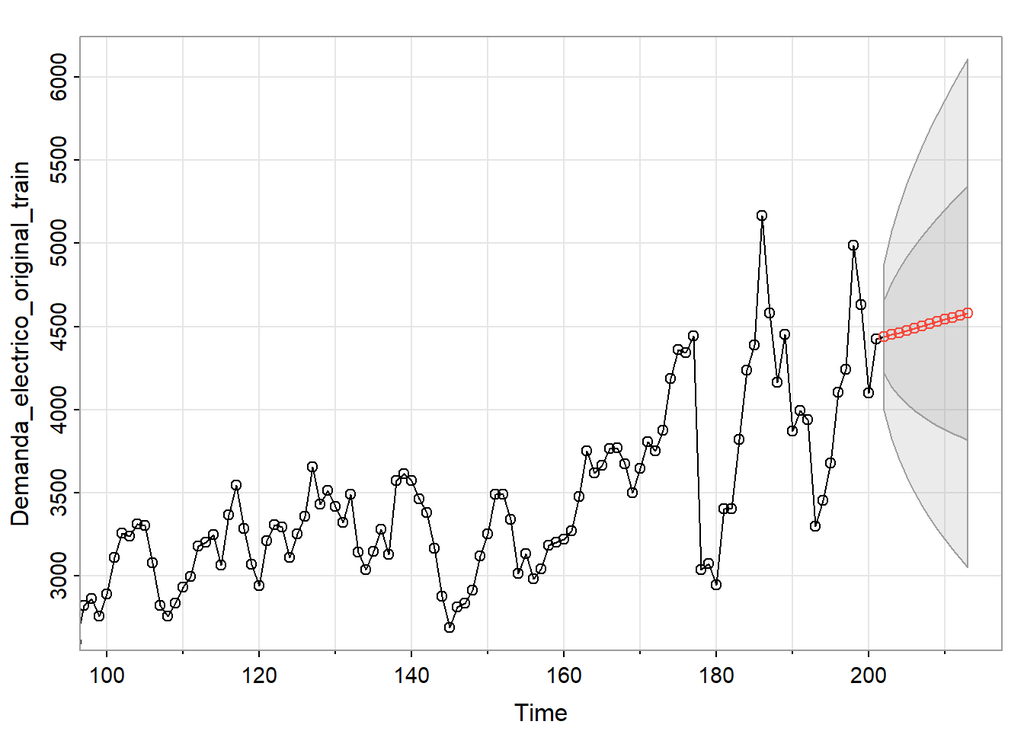

```r
pred_ARIMA_AUTO_Demanda_electrico_original_ts
```

```
## $pred
## Time Series:
## Start = 202
## End = 213
## Frequency = 1
##  [1] 4437.414 4450.438 4463.462 4476.486 4489.510 4502.534 4515.558 4528.582
##  [9] 4541.606 4554.631 4567.655 4580.679
##
## $se
## Time Series:
## Start = 202
## End = 213
## Frequency = 1
##  [1] 220.2614 311.4967 381.5040 440.5229 492.5196 539.5282 582.7570 622.9934
##  [9] 660.7843 696.5279 730.5246 763.0080
```

```r
accuracy(Demanda_electrico_original_test ,pred_ARIMA_AUTO_Demanda_electrico_original_ts$pred )
```

```
##                ME     RMSE      MAE      MPE     MAPE      ACF1 Theil's U
## Test set 810.7797 959.3799 841.1713 17.90831 18.59038 0.6187353  76.77737
```

```r
ARIMA_AUTO_Demanda_electrico_original_ts  <- auto.arima(Demanda_electrico_original_train)
ARIMA_AUTO_Demanda_electrico_original_ts
```

```
## Series: Demanda_electrico_original_train
## ARIMA(0,1,0)
##
## sigma^2 = 48685:  log likelihood = -1363.1
## AIC=2728.2   AICc=2728.22   BIC=2731.5
```

El Auto.Arima, arroja un modelo (0,1,0)

```r
pred_ARIMA_AUTO_Demanda_electrico_original_ts_v_train_recortado <- sarima.for(Demanda_electrico_train_V2, n.ahead=12,0,1,0)
```

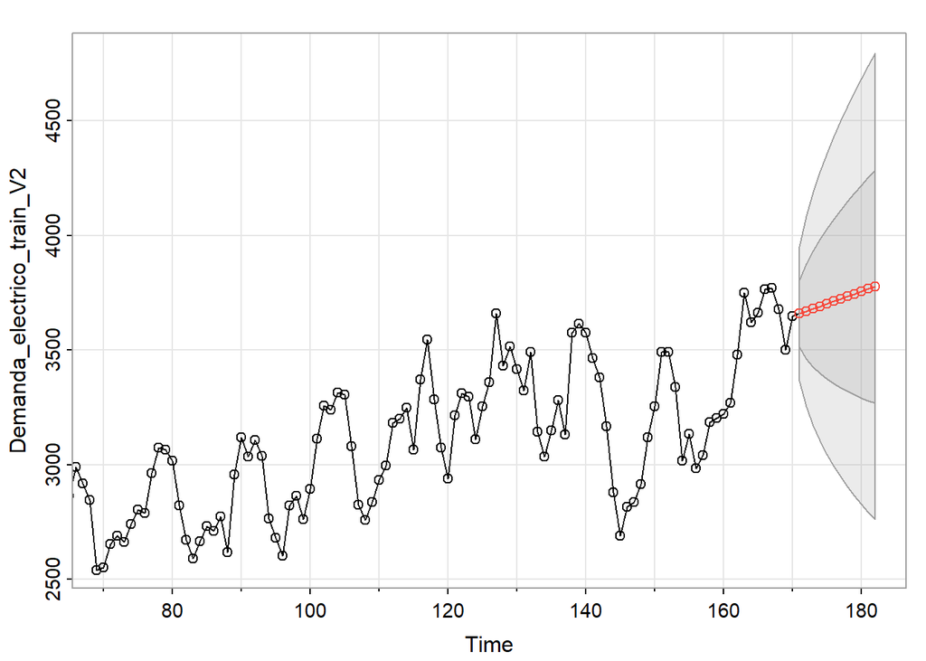

```r
pred_ARIMA_AUTO_Demanda_electrico_original_ts_v_train_recortado
```

```
## $pred
## Time Series:
## Start = 171
## End = 182
## Frequency = 1
##  [1] 3658.417 3669.233 3680.050 3690.867 3701.683 3712.500 3723.317 3734.133
##  [9] 3744.950 3755.767 3766.584 3777.400
##
## $se
## Time Series:
## Start = 171
## End = 182
## Frequency = 1
##  [1] 146.6946 207.4575 254.0825 293.3892 328.0191 359.3269 388.1175 414.9150
##  [9] 440.0838 463.8891 486.5310 508.1650
```

```r
accuracy(Demanda_electrico_original_test ,pred_ARIMA_AUTO_Demanda_electrico_original_ts_v_train_recortado$pred )
```

```
##                ME     RMSE      MAE       MPE     MAPE      ACF1 Theil's U
## Test set 19.64179 508.3177 437.4801 0.4392116 11.82543 0.6148495  44.62985
```

### Transformando la variable dependiente (LOG(Y)) a la serie 3 (Demanda_electrico) ORIGINAL

```r
# Load the TTR package
library(TTR)

Demanda_electrico_ts_log <- log(Demanda_electrico_ts)
```

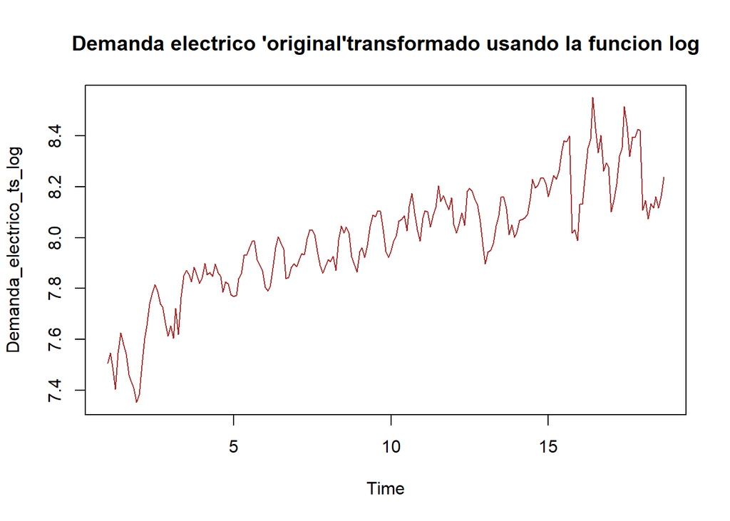

```r
plot(Demanda_electrico_ts_log, col = "brown", main = "Demanda electrico 'original'transformado usando la funcion log")
```